# Projeto: análise de um conjunto de dados referente aos tripulantes e passageiros a bordo do Titanic

## Conteúdo

- Introdução
- Data Wrangling
- Propriedades Gerais
- Observações sobre os rótulos de colunas
- Data Cleaning
- Remoção de colunas desnecessárias
- Atualização do padrão dos rótulos de coluna
- Tratamento de colunas com valores nulos
- Mudanças de tipo de dados
- Exploratory Data Analysis
- Questão 1: qual é a relação entre a idade e o fato de ser um sobrevivente ou um não-sobrevivente?
- Questão 2: qual a relação entre a classe do bilhete entre os sobreviventes e os não-sobreviventes?
- Questão 3: qual a relevância do sexo em relação à sobrevivência?
- Conclusões
- Considerações Finais

## Introdução

*"O acidente do RMS Titatic é um dos mais infames naufrágios da história. Em 15 de abril de 1912, durante sua viagem de estreia, o Titanic afundou depois de colidir com um iceberg provocando a morte de 1502 dos seus 2224 passageiros e tripulação. Tal tragédia chocou a comunidade internacional e levou a regulamentos de segurança mais rígidos para embarcações"*  
*(tradução livre do [**texto original**](https://www.kaggle.com/c/titanic))*  
A presente análise tem o untuito de explorar um dataset que contém dados dos passageiros e da tripulação do RMS Titanic em sua primeira e única viagem. O objetivo é levantar questões relevantes a respeito do naufrário através da aplicação de técnicas de análises de dados e de estatística descritiva.

```python
# importação de pacotes e carregamento dos dados
import pandas as pd
import matplotlib.pyplot as plt
import seaborn as sns

%matplotlib inline

df = pd.read_csv('titanic-data-6.csv')
```

## Data Wrangling

### Propriedades Gerais

```python
#(número de linhas, número de colunas)
df.shape
```

```
(891, 12)
```

```python
df.info()
```

```
<class 'pandas.core.frame.DataFrame'>
RangeIndex: 891 entries, 0 to 890
Data columns (total 12 columns):
PassengerId    891 non-null int64
Survived       891 non-null int64
Pclass         891 non-null int64
Name           891 non-null object
Sex            891 non-null object
Age            714 non-null float64
SibSp          891 non-null int64
Parch          891 non-null int64
Ticket         891 non-null object
Fare           891 non-null float64
Cabin          204 non-null object
Embarked       889 non-null object
dtypes: float64(2), int64(5), object(5)
memory usage: 83.6+ KB
```

Inicialmente o dataset apresenta 891 linhas e 12 colunas. Nota-se expressiva ausência de valores nas colunas **Age** e **Cabin** (em especial na última, pois somente 23% dos dados da coluna foram preenchidos).

#### Observações sobre os rótulos de colunas:

- Survived: 0 significa que o passageiro em questão não sobreviveu e 1, que o passageiro sobreviveu
- Pclass: classe da passage (1 é primeira classe, etc...)
- SibSp: número de irmãos / cônjuges a bordo do navio
- Parch: número de pais / filhos a bordo do navio
- Fare: tarifa paga pelo passageiro
- Cabin: número da cabine
- Embarked: local de embarque (C = Cherbourg, Q = Queenstown, S = Southampton)

*Para mais detalhes consultar [este link](https://www.kaggle.com/c/titanic/data)*

```python
#estrutura inicial do dataset
df.head()
```

|  | PassengerId | Survived | Pclass | Name | Sex | Age | SibSp | Parch | Ticket | Fare | Cabin | Embarked |
| --- | --- | --- | --- | --- | --- | --- | --- | --- | --- | --- | --- | --- |
| 0 | 1 | 0 | 3 | Braund, Mr. Owen Harris | male | 22.0 | 1 | 0 | A/5 21171 | 7.2500 | NaN | S |
| 1 | 2 | 1 | 1 | Cumings, Mrs. John Bradley (Florence Briggs Th... | female | 38.0 | 1 | 0 | PC 17599 | 71.2833 | C85 | C |
| 2 | 3 | 1 | 3 | Heikkinen, Miss. Laina | female | 26.0 | 0 | 0 | STON/O2. 3101282 | 7.9250 | NaN | S |
| 3 | 4 | 1 | 1 | Futrelle, Mrs. Jacques Heath (Lily May Peel) | female | 35.0 | 1 | 0 | 113803 | 53.1000 | C123 | S |
| 4 | 5 | 0 | 3 | Allen, Mr. William Henry | male | 35.0 | 0 | 0 | 373450 | 8.0500 | NaN | S |

### Data Cleaning

Como se pode notar na seção anterior alguns ajustes precisam ser feitos no dataset para garantir a qualidade da análise.

#### Remoção de colunas desnecessárias

Os números apresentados na coluna **PassengerId** acompanham o índice automático atribuído pelo *pandas*. Neste caso pode-se optar em transformar a coluna citada em índice ou excluí-la e utilizar o índice automático. A segunda opção foi escolhida. Para fins desta análise as seguintes colunas serão desconsideradas: PassengerId, Name, SibSp, Parch, Ticket, Fare, Cabin, Embarked. Tal decisão deve-se ao fato de a observação inicial dos dados apontar a irrelevância das colunas desconsideradas na questão da sobrevivência dos passageiros e da tripulação.

```python
#remoção de colunas
cols_to_drop = ['PassengerId', 'Name', 'SibSp', 'Parch', 'Ticket', 'Fare', 'Cabin', 'Embarked']

df.drop(cols_to_drop, axis=1, inplace=True)

#verificação
df.head()
```

|  | Survived | Pclass | Sex | Age |
| --- | --- | --- | --- | --- |
| 0 | 0 | 3 | male | 22.0 |
| 1 | 1 | 1 | female | 38.0 |
| 2 | 1 | 3 | female | 26.0 |
| 3 | 1 | 1 | female | 35.0 |
| 4 | 0 | 3 | male | 35.0 |

#### Atualização do padrão dos rótulos de coluna

Para facilitar a legibilidade os rótulos serão atualizados de forma a apresentarem apenas letras minúsculas

```python
df.rename(columns = lambda x: x.lower(), inplace=True)

df.head()
```

|  | survived | pclass | sex | age |
| --- | --- | --- | --- | --- |
| 0 | 0 | 3 | male | 22.0 |
| 1 | 1 | 1 | female | 38.0 |
| 2 | 1 | 3 | female | 26.0 |
| 3 | 1 | 1 | female | 35.0 |
| 4 | 0 | 3 | male | 35.0 |

#### Tratamento de colunas com valores nulos

Ao se verificar a estrutura atual do dataframe pode-se notar que a coluna **age** apresenta 177 valores nulos. Como essas linhas representam 19,86% do dataframe seria imprudente descartá-las da análise. Para corrigir o problema os valores nulos serão preenchidos com a média das idades apresentadas na coluna citada.

```python
df.info()
```

```
<class 'pandas.core.frame.DataFrame'>
RangeIndex: 891 entries, 0 to 890
Data columns (total 4 columns):
survived    891 non-null int64
pclass      891 non-null int64
sex         891 non-null object
age         714 non-null float64
dtypes: float64(1), int64(2), object(1)
memory usage: 27.9+ KB
```

```python
df['age'].isnull().sum()
```

```
177
```

```python
#cálculo da média das idades
age_mean = df['age'].mean()

#preenchimento dos valores vazios na coluna "age"
df['age'].fillna(age_mean, inplace=True)

#verificação da operação
df['age'].isnull().sum()
```

```
0
```

#### Mudanças de tipo de dados

Os dados da coluna **survived** são do tipo *int* e os da coluna **age**, *float*. Para melhorar a legibidade dos dados será usado o tipo *bool* para **survived** e *int* para **age**

```python
#conversão da coluna survived
df['survived'] = df['survived'].astype(bool)

#conversão da coluna age
df['age'] = df['age'].astype(int)
```

```python
df.head()
```

|  | survived | pclass | sex | age |
| --- | --- | --- | --- | --- |
| 0 | False | 3 | male | 22 |
| 1 | True | 1 | female | 38 |
| 2 | True | 3 | female | 26 |
| 3 | True | 1 | female | 35 |
| 4 | False | 3 | male | 35 |

## Exploratory Data Analysis

### Questão 1: qual é a relação entre a idade e o fato de ser um sobrevivente ou um não-sobrevivente?

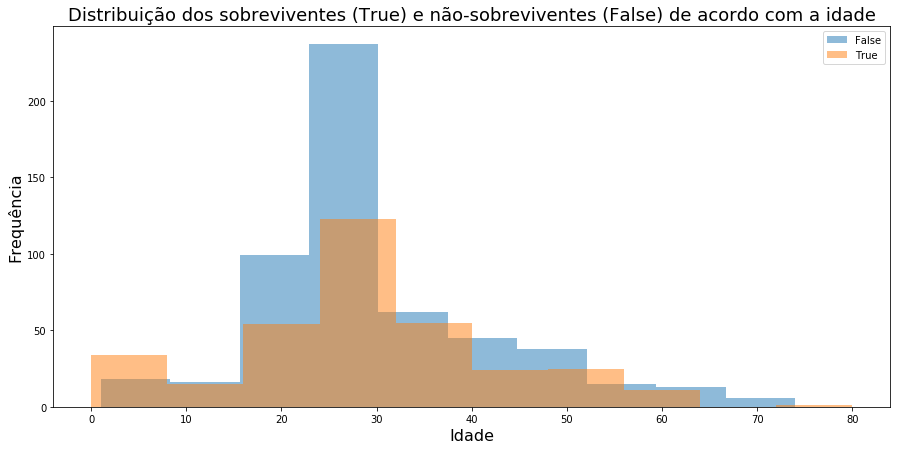

```python
# definição do tamanho padrão para a fonte aplicada a legenda dos eixos
axis_text_fontsize = 16

# definição do tamanho padrão dos gráficos utilizados na análise
standard_figsize = (15,7)

# definição do tamanho padrão para o título dos gráficos
standard_title_fontsize = 18

df.groupby('survived')['age'].plot.hist(alpha=0.5, figsize=standard_figsize);

# definição dos textos dos eixos e do título
plt.ylabel('Frequência', fontsize=axis_text_fontsize);
plt.xlabel('Idade', fontsize=axis_text_fontsize);
plt.title('Distribuição dos sobreviventes (True) e não-sobreviventes (False) de acordo com a idade', \
          fontsize=standard_title_fontsize);

#mostrar legenda
plt.legend();
```

Para evidenciar de forma mais concisa a relação proposta optou-se pela formação de grupos de acordo com a faixa etária:

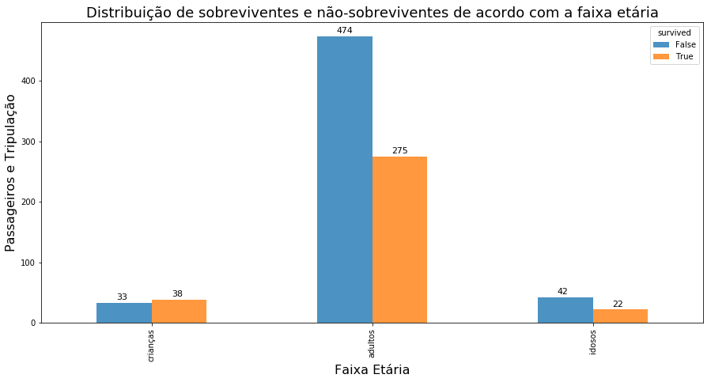

```python
#separação dos dados de acordo com a faixa etária
df['age_group'] = pd.cut(df['age'], [0, 14, 50, 150], labels=['crianças', 'adultos', 'idosos'])

# plot do gráfico
ax = df.groupby(['age_group', 'survived']).size().unstack().plot.bar(alpha=0.8, figsize=standard_figsize);

# definição das legendas de eixos e do título
ax.set_title('Distribuição de sobreviventes e não-sobreviventes de acordo com a faixa etária', \
             fontsize=standard_title_fontsize);
ax.set_xlabel('Faixa Etária', fontsize=axis_text_fontsize);
ax.set_ylabel('Passageiros e Tripulação', fontsize=axis_text_fontsize);

# exibição da legenda dos valores sobre as colunas
for i in ax.patches:
    ax.text(i.get_x()+0.09, i.get_height()+5, str(round((i.get_height()), 2)), fontsize=11)
```

A partir do gráfico acima conclui-se que a maioria das crianças sobreviveu, enquanto a maioria dos adultos e idosos sucumbiu ao acidente.

### Questão 2: qual a relação entre a classe do bilhete entre os sobreviventes e os não-sobreviventes?

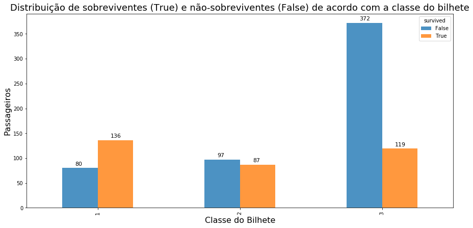

```python
# agrupamento dos dados de acordo com a sobrevivência e a classe do bilhete
ax = df.groupby(['pclass', 'survived']).size().unstack().plot.bar(figsize=standard_figsize, alpha=0.8)

# definição de legendas para o título e para os eixos
ax.set_title('Distribuição de sobreviventes (True) e não-sobreviventes (False) de acordo com a classe do bilhete', \
             fontsize=standard_title_fontsize)
ax.set_ylabel('Passageiros', fontsize=axis_text_fontsize)
ax.set_xlabel('Classe do Bilhete', fontsize=axis_text_fontsize)

# exibição dos valores sobre as colunas
for i in ax.patches:
    ax.text(i.get_x()+0.09, i.get_height()+5, str(round((i.get_height()), 2)), fontsize=11)
```

Com base no gráfico acima pode-se afirmar que, dentre passageiros de uma mesma classe, a maior parte das baixas ocorreu entre passageiros da classe C (3) enquanto o maior número de sobreviventes está entre os passageiros da classe A (1).

### Questão 3: qual a relevância do sexo em relação à sobrevivência?

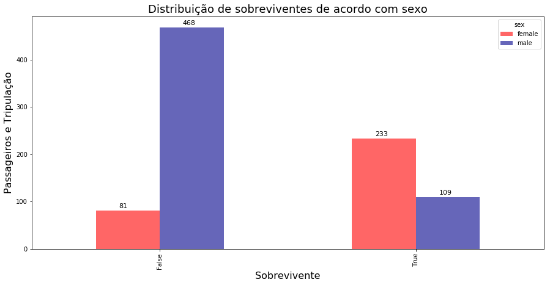

```python
# agrupamento dos dados de acordo com a sobrevivência e com o sexo
ax = df.groupby(['survived', 'sex']).size().unstack().plot.bar(alpha=0.6,figsize=standard_figsize, \
                                                               color=['red', 'DarkBlue']);

# definição das legendas dos eixos e do título
ax.set_title('Distribuição de sobreviventes de acordo com sexo', fontsize=standard_title_fontsize);
ax.set_ylabel('Passageiros e Tripulação', fontsize=axis_text_fontsize);
ax.set_xlabel('Sobrevivente', fontsize=axis_text_fontsize);

#exibição dos valores sobre as colunas
for i in ax.patches:
    ax.text(i.get_x()+0.09, i.get_height()+5, str(round((i.get_height()), 2)), fontsize=11)
```

De acordo com o histograma acima nota-se que a maior parte dos sobreviventes é do sexo feminino.

## Conclusões

### Considerações sobre as limitações da análise

A presente análise se baseia em um dataset que contém 891 registros (como demonstrado em **Propriedades Gerais**). Levando-se em consideração que o Titanic apresentava uma contagem de 2224 passageiros e tripulantes na viagem em que ocorreu o acidente o conjunto de dados representa **40,06%** do número total de pessoas a bordo do navio. Tal fato aliado a ausência de testes estatísticos fazem com que essa análise tenha um alcance limitado mas apresente resultados coerentes, concisos e representativos. A presença de valores nulos ao longo do conjunto de dados sempre é uma questão delicada que pode ser abordada de várias formas diferentes, como: ignorar os registros que apresentam valores nulos, substituir valores por outros (média, por exemplo), construir modelos para prever valores faltantes, etc. Na seção Tratamento de colunas com valores nulos nota-se a presença de um exemplo da abordagem na qual as lacunas nos valores da coluna **age** foram preenchidas com a média obtida com os valores da própria coluna. Existem abordagens estatísticas que favorecem a utilização da mediana a despeito da média porque ela apresenta um melhor valor *típico* por não ser tão distorcida nos valores das extremidades. No conjunto de dados em questão os valores da média e da mediana são muito próximos (como demonstrado abaixo), o que faz com que o valor considerado não comprometa expressivamente a análise.

```python
print('Média dos valores da coluna "age": {}'.format(df['age'].mean()))
print('Mediana da coluna "age": {}'.format(df['age'].median()))
```

```
Média dos valores da coluna "age": 29.544332210998878
Mediana da coluna "age": 29.0
```